# Kenai River Baseline Water Quality Monitoring: 2025 Field Season Summary

**PRELIMINARY** - Results subject to change pending QA/QC review and EPA WQX submission.

*Kenai Watershed Forum | 44129 Sterling Highway, Soldotna, AK 99669 | www.kenaiwatershed.org*

*Benjamin Meyer, Research Coordinator | (907) 260-5449 | hydrology@kenaiwatershed.org*

*April 2026*

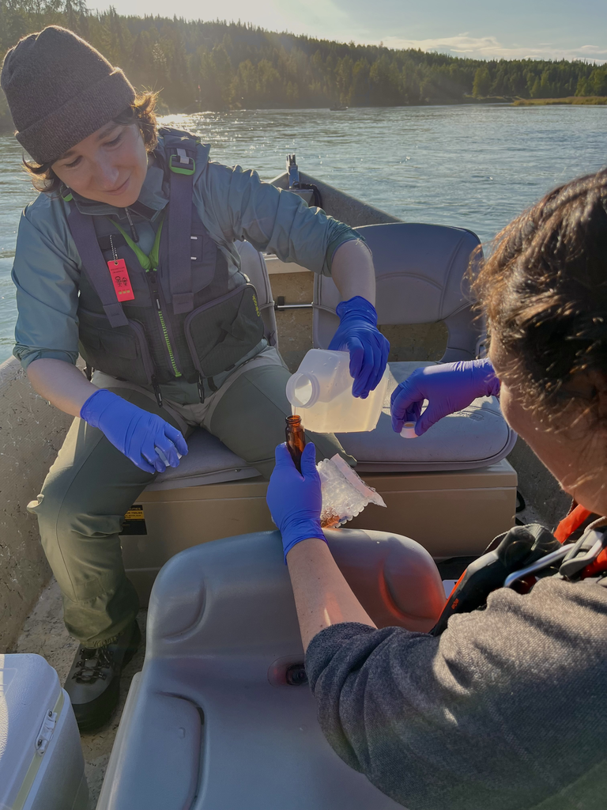

*Alaska Department of Environmental Conservation staff collect water samples on the middle Kenai River in 2025.*

> **PRELIMINARY RESULTS**: Data in this summary have not undergone full QA/QC review and have not been submitted to the U.S. EPA Water Quality Exchange (WQX). Values are subject to change. This document is intended for internal and partner communication only.

## Executive Summary

Kenai Watershed Forum (KWF) coordinated bi-annual baseline water quality monitoring events on the Kenai River and its major tributaries in 2025. Sampling was completed at 20 sites in spring (April 30, 2025) and 22 sites in summer (July 23, 2025), spanning from Kenai Lake (River Mile 82) to the river mouth (River Mile 1.5). Laboratory analysis of metals, nutrients, and hydrocarbons was performed by SGS North America; fecal coliform (FC) and total suspended solids (TSS) were analyzed by the City of Soldotna Wastewater Treatment Plant; field parameters (temperature, specific conductance, dissolved oxygen, and pH) were measured with a YSI ProQuatro field meter, and turbidity was measured with a Hach 2100P portable turbidimeter.

Results for most parameters were within applicable water quality standards. Notable preliminary findings include:

- **Iron** exceeded the 1 mg/L aquatic life chronic criterion at 11 site-events across both seasons. Elevated iron is a recurring pattern in the Kenai River watershed, particularly at lower-river and wetland-draining tributary sites, and is consistent with the long-term monitoring record.
- **Lead** (dissolved) exceeded its hardness-adjusted aquatic life chronic threshold at one summer site (Beaver Creek, RM 10). The corresponding field duplicate at that site was non-detect, raising a question about the result’s veracity; this result will receive additional scrutiny during full QA/QC review.
- **Hydrocarbons (BTEX)** were below laboratory detection limits at all four summer sampling sites.
- No threshold exceedances were identified for Arsenic, Cadmium, Chromium, Copper, Zinc, Nitrate + Nitrite, or Fecal Coliform.

**These results are preliminary.** Data have not undergone full QA/QC review and have not been submitted to the U.S. EPA Water Quality Exchange (WQX). Values are subject to change. Next steps include formal QA/QC evaluation per the KWF Quality Assurance Project Plan, data submission to EPA WQX, and integration of 2025 results into the KWF long-term baseline water quality report.

## Acronyms

Table 1: Acronyms used in this report.

| Acronym | Definition |
| --- | --- |
| ADEC | Alaska Department of Environmental Conservation |
| BTEX | Benzene, Toluene, Ethylbenzene, and Xylenes (petroleum hydrocarbons) |
| CDX | EPA Central Data Exchange (data submission portal) |
| EPA | U.S. Environmental Protection Agency |
| FC | Fecal Coliform |
| J (flag) | Qualified detection; value is between the LOD and the LOQ |
| KWF | Kenai Watershed Forum |
| LOD | Laboratory Detection Limit; the lowest concentration at which a compound can be reliably detected |
| LOQ | Laboratory Quantitation Limit; the lowest concentration that can be reliably measured and reported |
| QAPP | Quality Assurance Project Plan |
| QC | Quality Control |
| RM | River Mile |
| RPD | Relative Percent Difference; a measure of agreement between two measurements of the same sample |
| SGS | SGS North America (environmental laboratory) |
| SWWTP | Soldotna Wastewater Treatment Plant |
| TSS | Total Suspended Solids |
| U (flag) | Non-detect; the compound was not detected at or above the LOD |
| WQP | EPA Water Quality Portal (public data repository) |
| WQX | Water Quality Exchange (EPA data standard and submission system) |

## Overview

Kenai Watershed Forum (KWF) has coordinated baseline water quality monitoring on the Kenai River and its major tributaries since 2000. More information about the project and access to data and reports are available at the links below.

[output not shown]

Sampling occurs twice each year, in spring (April/May) and summer (July/Aug) at up to 22 established monitoring sites spanning the river from Kenai Lake (River Mile 82) to the river mouth (River Mile 1.5). Laboratory analysis is performed by SGS North America; fecal coliform (FC) and total suspended solids (TSS) analysis is performed by the City of Soldotna Wastewater Treatment Plant (SWWTP).

In 2026 and in years going forward, TSS samples will be processed by the City of Kenai Wastewater Treatment Plant.

Results are submitted to the U.S. EPA Water Quality Portal, where they are accessible to the public and used by the Alaska Department of Environmental Conservation (ADEC) in its Integrated Report on water quality conditions in Alaska.

## Study Area

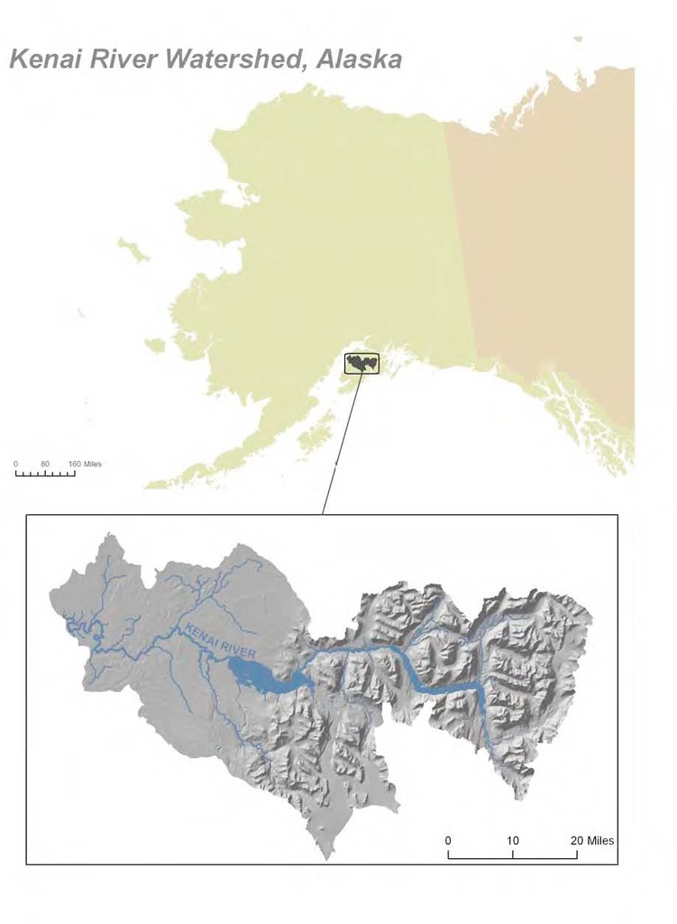

Figure 1: Location of the Kenai River Watershed within Alaska.

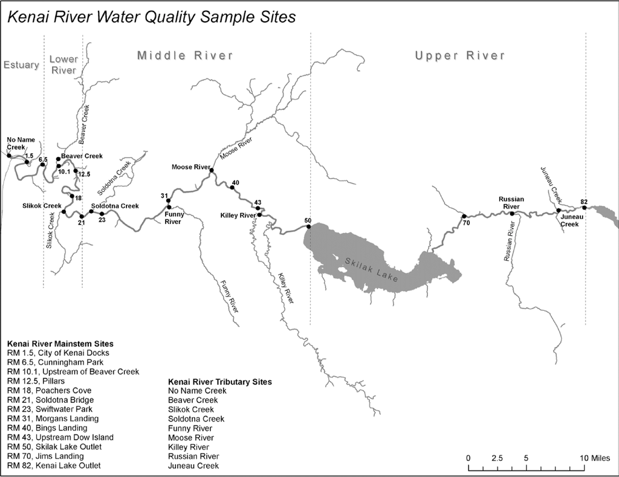

Figure 2: Location of water quality sampling sites on the Kenai River and its major tributaries.

## 2025 Sampling Events

Table 2: 2025 sampling events.

| Season | Date | Monitoring sites | Notes |
| --- | --- | --- | --- |
| Spring | April 30, 2025 | 20 | Metals and nutrients; TSS and FC |
| Summer | July 23, 2025 | 22 | Metals, nutrients, and hydrocarbons (BTEX); TSS and FC |

Hydrocarbon (BTEX) analysis is not conducted in spring by design: boat activity on the river is minimal in April and May, and the risk of petroleum-related contamination from vessel traffic is negligible during that period.

## Parameters Analyzed

Table 3: Parameters analyzed by season and analytical fraction. “Dissolved” metals were filtered through a 0.45 µm membrane prior to analysis; “Total” metals were unfiltered. FC and TSS were analyzed by SWWTP; temperature, specific conductance, dissolved oxygen, and pH by YSI ProQuatro meter; turbidity by Hach 2100P portable turbidimeter.

| Parameter group | Parameter | Fraction | Seasons sampled |
| --- | --- | --- | --- |
| Dissolved metals | Arsenic | Dissolved | Spring and Summer |
| Dissolved metals | Cadmium | Dissolved | Spring and Summer |
| Dissolved metals | Chromium | Dissolved | Spring and Summer |
| Dissolved metals | Lead | Dissolved | Spring and Summer |
| Metals | Copper | Dissolved | Spring and Summer |
| Metals | Copper | Total | Spring and Summer |
| Metals | Zinc | Dissolved | Spring and Summer |
| Metals | Zinc | Total | Spring and Summer |
| Total metals | Calcium | Total | Spring and Summer |
| Total metals | Iron | Total | Spring and Summer |
| Total metals | Magnesium | Total | Spring and Summer |
| Nutrients | Nitrate + Nitrite (as N) | Total | Spring and Summer |
| Nutrients | Total Phosphorus | Total | Spring and Summer |
| Hydrocarbons (BTEX) | Benzene | Volatile | Summer |
| Hydrocarbons (BTEX) | Ethylbenzene | Volatile | Summer |
| Hydrocarbons (BTEX) | Toluene | Volatile | Summer |
| Hydrocarbons (BTEX) | Total Xylenes | Volatile | Summer |
| Hydrocarbons (BTEX) | o-Xylene | Volatile | Summer |
| Hydrocarbons (BTEX) | p/m-Xylene | Volatile | Summer |
| Field parameters | Dissolved Oxygen | Total | Spring and Summer |
| Field parameters | Fecal Coliform | None | Spring and Summer |
| Field parameters | Specific Conductance | Total | Spring and Summer |
| Field parameters | Total Suspended Solids | Suspended | Spring and Summer |
| Field parameters | Turbidity | Total | Spring and Summer |
| Field parameters | Water Temperature | Total | Spring and Summer |
| Field parameters | pH | Total | Spring and Summer |

## Preliminary Results

The tables below summarize measured concentrations across all primary sampling sites. Ranges show the minimum and maximum detected values; non-detected parameters show the laboratory LOD. Some parameters were analyzed at a subset of sites. “J” indicates a qualified detection between the LOD and LOQ.

### Spring 2025 (April 30, 2025)

Table 4: Spring 2025 preliminary results summary.

| Parameter group | Parameter | Fraction | Unit | n sites | Result range |
| --- | --- | --- | --- | --- | --- |
| Dissolved metals | Arsenic | Dissolved | ug/L | 11 | 1.54 - 5.24 (6/11 detected) |
| Dissolved metals | Cadmium | Dissolved | ug/L | 11 | Non-detect (LOD: 0.375) |
| Dissolved metals | Chromium | Dissolved | ug/L | 11 | Non-detect (LOD: 3.75) |
| Dissolved metals | Lead | Dissolved | ug/L | 11 | Non-detect (LOD: 1.50) |
| Metals | Copper | Dissolved | ug/L | 11 | 19.0 - 19.0 (1/11 detected) |
| Metals | Copper | Total | ug/L | 11 | 1.42 - 48.1 (3/11 detected) |
| Metals | Zinc | Dissolved | ug/L | 11 | 5.20 - 22.9 |
| Metals | Zinc | Total | ug/L | 11 | 3.84 - 54.6 (7/11 detected) |
| Total metals | Calcium | Total | mg/L | 19 | 9.05 - 158. |
| Total metals | Iron | Total | mg/L | 19 | 0.0845 - 17.8 (16/19 detected) |
| Total metals | Magnesium | Total | mg/L | 19 | 1.00 - 396. |
| Nutrients | Nitrate + Nitrite (as N) | Total | mg/L | 20 | 0.0566 - 1.11 |
| Nutrients | Total Phosphorus | Total | mg/L | 20 | 0.0151 - 0.473 (8/20 detected) |
| Field parameters | Dissolved Oxygen | Total | mg/L | 16 | 10.7 - 16.9 |
| Field parameters | Fecal Coliform | None | CFU/100mL | 20 | 1.00 - 164. (12/20 detected) |
| Field parameters | Specific Conductance | Total | uS/cm | 19 | 67.0 - 2.14e+04 |
| Field parameters | Total Suspended Solids | Suspended | mg/L | 22 | 0.200 - 493. (20/22 detected) |
| Field parameters | Turbidity | Total | NTU | 19 | 0.505 - 344. |
| Field parameters | Water Temperature | Total | deg C | 19 | 2.60 - 6.10 |
| Field parameters | pH | Total | s.u. | 19 | 6.14 - 7.80 |

### Summer 2025 (July 23, 2025)

Table 5: Summer 2025 preliminary results summary.

| Parameter group | Parameter | Fraction | Unit | n sites | Result range |
| --- | --- | --- | --- | --- | --- |
| Dissolved metals | Arsenic | Dissolved | ug/L | 13 | 1.50 - 7.57 (6/13 detected) |
| Dissolved metals | Cadmium | Dissolved | ug/L | 13 | Non-detect (LOD: 0.375) |
| Dissolved metals | Chromium | Dissolved | ug/L | 13 | Non-detect (LOD: 3.75) |
| Dissolved metals | Lead | Dissolved | ug/L | 13 | 7.36 - 7.36 (1/13 detected) |
| Metals | Copper | Dissolved | ug/L | 13 | Non-detect (LOD: 2.25) |
| Metals | Copper | Total | ug/L | 13 | 1.25 - 36.0 (3/13 detected) |
| Metals | Zinc | Dissolved | ug/L | 13 | 17.1 - 17.1 (1/13 detected) |
| Metals | Zinc | Total | ug/L | 13 | 3.36 - 87.2 (8/13 detected) |
| Total metals | Calcium | Total | mg/L | 22 | 6.54 - 24.9 |
| Total metals | Iron | Total | mg/L | 22 | 0.215 - 26.4 (17/22 detected) |
| Total metals | Magnesium | Total | mg/L | 22 | 0.920 - 13.9 |
| Nutrients | Nitrate + Nitrite (as N) | Total | mg/L | 22 | 0.0532 - 1.02 |
| Nutrients | Total Phosphorus | Total | mg/L | 22 | 0.0156 - 0.662 (9/22 detected) |
| Hydrocarbons (BTEX) | Benzene | Volatile | ug/L | 4 | Non-detect (LOD: 0.300) |
| Hydrocarbons (BTEX) | Ethylbenzene | Volatile | ug/L | 4 | Non-detect (LOD: 0.750) |
| Hydrocarbons (BTEX) | Toluene | Volatile | ug/L | 4 | Non-detect (LOD: 0.750) |
| Hydrocarbons (BTEX) | Total Xylenes | Volatile | ug/L | 4 | Non-detect (LOD: 2.25) |
| Hydrocarbons (BTEX) | o-Xylene | Volatile | ug/L | 4 | Non-detect (LOD: 0.750) |
| Hydrocarbons (BTEX) | p/m-Xylene | Volatile | ug/L | 4 | Non-detect (LOD: 1.50) |
| Field parameters | Dissolved Oxygen | Total | mg/L | 22 | 8.30 - 12.7 |
| Field parameters | Fecal Coliform | None | CFU/100mL | 22 | 1.00 - 400. (15/22 detected) |
| Field parameters | Specific Conductance | Total | uS/cm | 22 | 0.0399 - 145. |
| Field parameters | Total Suspended Solids | Suspended | mg/L | 22 | 1.00 - 763. |
| Field parameters | Turbidity | Total | NTU | 22 | 0.490 - 896. |
| Field parameters | Water Temperature | Total | deg C | 22 | 8.50 - 16.7 |
| Field parameters | pH | Total | s.u. | 22 | 6.30 - 8.03 |

BTEX compounds were analyzed at 4 sites: RM 1.5 (Kenai City Dock), RM 6.5 (Cunningham Park), RM 40 (Bing’s Landing), and RM 43 (Upstream of Dow Island). All BTEX compounds were below laboratory detection limits at all four sites.

## Preliminary Threshold Comparison

The table below identifies measurements that preliminarily exceed applicable water quality standards. Two categories of standards are referenced:

- **Aquatic life chronic standards** (Alaska Department of Environmental Conservation 2023b; U.S. Environmental Protection Agency 2024): protect aquatic organisms and salmon habitat; these are the primary regulatory standards for the Kenai River.
- **Drinking water standards** (Alaska Department of Environmental Conservation 2023a): included for context; the Kenai River is not a designated drinking water source.

Thresholds for hardness-dependent metals (Cadmium, Chromium, Copper, Lead, Zinc) are computed per site using measured calcium and magnesium concentrations, following ADEC criteria formulas (Alaska Department of Environmental Conservation 2023b). Those input values are themselves preliminary and may change after QA/QC. **No regulatory determination can be made from these data.**

Table 6: Preliminary threshold comparisons for values with flagged potential exceedances. “Ratio” = measured value divided by the applicable threshold. PRELIMINARY: values have not been fully QA/QC reviewed. Hardness-dependent thresholds are computed per site from preliminary Ca/Mg values using ADEC 18 AAC 70 chronic aquatic life criteria formulas and may change after QA/QC review.

| Season | Site | Parameter | Measured | Threshold | Unit | Ratio | Standard |
| --- | --- | --- | --- | --- | --- | --- | --- |
| Spring | RM 0-No Name Creek | Iron | 4.47 | 1.00 | mg/L | 4.5 | Aquatic life chronic (ADEC 18 AAC 70 / USEPA 1976) |
| Spring | RM 1.5 -Kenai City Dock | Iron | 17.80 | 1.00 | mg/L | 17.8 | Aquatic life chronic (ADEC 18 AAC 70 / USEPA 1976) |
| Spring | RM 10-Beaver Creek | Iron | 3.46 | 1.00 | mg/L | 3.5 | Aquatic life chronic (ADEC 18 AAC 70 / USEPA 1976) |
| Spring | RM 19-Slikok Creek | Iron | 1.47 | 1.00 | mg/L | 1.5 | Aquatic life chronic (ADEC 18 AAC 70 / USEPA 1976) |
| Spring | RM 22-Soldotna Creek | Iron | 1.13 | 1.00 | mg/L | 1.1 | Aquatic life chronic (ADEC 18 AAC 70 / USEPA 1976) |
| Spring | RM 30-Funny River | Iron | 1.04 | 1.00 | mg/L | 1.0 | Aquatic life chronic (ADEC 18 AAC 70 / USEPA 1976) |
| Summer | RM0-No Name Creek | Iron | 3.61 | 1.00 | mg/L | 3.6 | Aquatic life chronic (ADEC 18 AAC 70 / USEPA 1976) |
| Summer | RM1.5-Kenai City Dock | Iron | 26.40 | 1.00 | mg/L | 26.4 | Aquatic life chronic (ADEC 18 AAC 70 / USEPA 1976) |
| Summer | RM10-Beaver Creek | Iron | 2.76 | 1.00 | mg/L | 2.8 | Aquatic life chronic (ADEC 18 AAC 70 / USEPA 1976) |
| Summer | RM19-Slikok Creek | Iron | 1.87 | 1.00 | mg/L | 1.9 | Aquatic life chronic (ADEC 18 AAC 70 / USEPA 1976) |
| Summer | RM6.5-Cunningham Park | Iron | 1.24 | 1.00 | mg/L | 1.2 | Aquatic life chronic (ADEC 18 AAC 70 / USEPA 1976) |
| Summer | RM10-Beaver Creek | Lead | 7.36 | 1.72 | ug/L | 4.3 | Aquatic life chronic (ADEC 18 AAC 70) |

**Iron** (11 site-events): Iron exceeds the 1 mg/L aquatic life chronic criterion (U.S. Environmental Protection Agency 1976; Alaska Department of Environmental Conservation 2023b) at several tributary and lower-river sites in both seasons. Elevated iron is common in glacially influenced and wetland-draining streams in the Kenai River watershed and is consistent with historical monitoring results. The most elevated values occur at RM 1.5 (Kenai City Dock), where tidal mixing substantially increases dissolved mineral content. These results will be evaluated in context of the full dataset during QA/QC review.

**Lead** (1 site-event): A dissolved lead concentration of 7.36 µg/L was measured at Beaver Creek (RM 10) during the summer sampling event. The hardness-adjusted aquatic life chronic threshold at that site is 1.72 µg/L, placing the measured value at 4.3× the threshold. This detection was confirmed by the laboratory above the reporting limit. **However, the corresponding field duplicate was non-detect for lead (see Field QC section below), which raises a question about the validity of this result.** It will receive additional scrutiny during the full QA/QC review.

No exceedances were identified for Arsenic, Cadmium, Chromium, Copper, Zinc, Nitrate + Nitrite (as N), or BTEX compounds.

## Field Quality Control

Field QC samples are collected alongside environmental samples to detect potential contamination introduced during collection, preservation, or transport, and to assess measurement precision. All results below are preliminary.

### Field Blanks (Metals)

Field blanks were collected at two sites per season and analyzed for the same suite of metals as primary samples. All results should ideally be non-detect; any detection in a field blank may indicate contamination introduced during sampling.

Table 7: Field blank detections (non-detect results not shown). “J” indicates a qualified trace detection between the LOD and LOQ.

| Season | Site | Parameter | Result |
| --- | --- | --- | --- |
| Spring | RM 1.5-Kenai City Dock | Zinc | J: 9.2 ug/L (below LOQ) |
| Spring | RM 19-Slikok Creek | Zinc | J: 6.74 ug/L (below LOQ) |
| Spring | RM 19-Slikok Creek | Zinc | J: 5.43 ug/L (below LOQ) |
| Summer | RM22-Soldotna Creek | Zinc | J: 3.61 ug/L (below LOQ) |

All field blank detections were for Zinc at trace levels below the reporting LOQ (J-flag). These low-level detections do not necessarily indicate problematic contamination, but they are noted for transparency and will be considered during QA/QC review of primary Zinc results.

### Trip Blanks (BTEX)

Trip blanks for hydrocarbon (BTEX) analysis were collected for the summer sampling event. A trip blank travels with the sample containers throughout collection and is used to detect contamination from the sampling process or transport. Two trip blanks covered the four BTEX sampling sites.

Table 8: Summer 2025 BTEX trip blank results. All compounds were non-detect in both trip blanks, indicating no contamination was introduced during sample collection or transport.

| Trip blank | Compound | Result |
| --- | --- | --- |
| RM1.5&6.5 trip blank | Benzene | Non-detect (LOD: 0.3 ug/L) |
| RM1.5&6.5 trip blank | Ethylbenzene | Non-detect (LOD: 0.75 ug/L) |
| RM1.5&6.5 trip blank | P & M -Xylene | Non-detect (LOD: 1.5 ug/L) |
| RM1.5&6.5 trip blank | Toluene | Non-detect (LOD: 0.75 ug/L) |
| RM1.5&6.5 trip blank | Xylenes (total) | Non-detect (LOD: 2.25 ug/L) |
| RM1.5&6.5 trip blank | o-Xylene | Non-detect (LOD: 0.75 ug/L) |
| RM40&43 trip blank | Benzene | Non-detect (LOD: 0.3 ug/L) |
| RM40&43 trip blank | Ethylbenzene | Non-detect (LOD: 0.75 ug/L) |
| RM40&43 trip blank | P & M -Xylene | Non-detect (LOD: 1.5 ug/L) |
| RM40&43 trip blank | Toluene | Non-detect (LOD: 0.75 ug/L) |
| RM40&43 trip blank | Xylenes (total) | Non-detect (LOD: 2.25 ug/L) |
| RM40&43 trip blank | o-Xylene | Non-detect (LOD: 0.75 ug/L) |

### Field Duplicates

Field duplicate samples were collected for all parameters at two sites per season. The RPD between a primary sample and its duplicate indicates measurement precision. Values below 10–20% RPD are generally considered acceptable. Only pairs where both the primary and duplicate produced detectable results are shown; non-detect pairs are excluded from RPD calculation.

Table 9: Field duplicate precision summary by site. RPD = relative percent difference between primary and duplicate samples. Parameters with RPD > 20% are listed; non-detect pairs are excluded.

| Season | Site | Pairs | RPD > 20% | Flagged parameters |
| --- | --- | --- | --- | --- |
| Spring | Poachers Cove | 10 | 1 | Total Suspended Solids |
| Spring | Soldotna Creek | 8 | 2 | Total Suspended Solids, Turbidity |
| Summer | Beaver Creek | 11 | 2 | Total Suspended Solids, Dissolved Oxygen |
| Summer | Swiftwater Park | 6 | 1 | Total Suspended Solids |

Note: The dissolved Lead result at Beaver Creek (RM 10, summer), flagged as a potential exceedance in Table 6, was detected at 7.36 µg/L in the primary sample but was non-detect in the field duplicate. This discrepancy does not appear in Table 9 (since non-detect duplicates are excluded from RPD calculation), but it is an important QC flag that will receive additional scrutiny during QA/QC review.

## Next Steps

The following steps remain before 2025 data are finalized:

1. **Full QA/QC review** in accordance with the KWF QAPP, including holding time verification, matrix spike recovery assessment, and resolution of the Lead field duplicate discrepancy at Beaver Creek.
2. **Data submission to EPA WQX** via the EPA Central Data Exchange (CDX). Upon successful upload, 2025 results will be publicly accessible through the EPA Water Quality Portal and How’s My Waterway.
3. **Integration into the KWF baseline water quality report**, covering the full period of record (2000–present).

Questions about this summary may be directed to Kenai Watershed Forum at kenaiwatershed.org. The data processing pipeline for this report is maintained at github.com/Kenai-Watershed-Forum/kenai-river-wqx for technical inquiries.

## Appendix: Project Collaborators

**Current Entities Contributing In-kind and/or Financial Support**

- Alaska Department of Environmental Conservation
- Alaska Department of Fish and Game
- Alaska Department of Natural Resources
- City of Kenai
- City of Soldotna
- Cook Inlet Aquaculture Association
- Defenders of Wildlife
- Kenai National Wildlife Refuge
- Kenai Peninsula Borough
- Kenai Peninsula Fish Habitat Partnership
- Kenai Peninsula Trout Unlimited
- Kenaitze Indian Tribe
- Mister Kenai Sportfishing
- Salamatof Tribe
- SGS North America, Inc.
- Tyonek Tribal Conservation District
- U.S. Fish and Wildlife Service
- U.S. Forest Service

*AI disclosure: This document was drafted with assistance from Posit Assistant, an AI tool developed by Posit PBC. Posit Assistant was used to help write data processing code, interpret preliminary results, and draft text. All analytical decisions and factual content were developed by KWF staff. The preliminary findings and regulatory comparisons in this document reflect KWF’s own evaluation of preliminary data.*

## References

Alaska Department of Environmental Conservation. 2023a. “Alaska Drinking Water Regulations: 18 AAC 80.” Juneau, AK: Alaska Department of Environmental Conservation. https://dec.alaska.gov/eh/dw/.

———. 2023b. “Alaska Water Quality Standards: 18 AAC 70.” Juneau, AK: Alaska Department of Environmental Conservation. https://dec.alaska.gov/water/water-quality/standards/.

U.S. Environmental Protection Agency. 1976. *Quality Criteria for Water*. Washington, D.C.: U.S. Environmental Protection Agency, Office of Water Planning; Standards.

———. 2024. “National Recommended Water Quality Criteria: Aquatic Life Criteria Table.” Washington, D.C.: U.S. Environmental Protection Agency, Office of Water. https://www.epa.gov/wqc/national-recommended-water-quality-criteria-aquatic-life-criteria-table.